# Educational implementation of sorting algorithms

Several sorting algorithms implemented in plain C language, with an extensible approach (new algorithms can be connected) and a simple visualization mechanism aimed to understand how they work.

The C code is portable to Windows, GNU/Linux and OS X, as the user interface is based on the [ncurses library](https://www.gnu.org/software/ncurses/).

The code is documented (in Spanish) with the [doxygen tool](http://www.stack.nl/~dimitri/doxygen/).

## Algorithms implemented

The algorithms currently implemented are the following (the function in the Algoritmos.c where each algorithm is coded is also indicated):

- Bubble sort - `ordBurbuja()`
- Improved bubble sort - `ordBurbujaMejorado()`
- Selection sort - `ordSeleccion()`
- Insertion sort - `ordInsercion()`
- Shaker sort (also known as cocktail sort) - `ordSacudida()`
- Shell sort - `ordShell()`
- Quick sort - `ordQuick()`

## Modules of the project

The project is made of the following modules:

- Definiciones.h: Definitions of the data types used in the application, such as `boolean` (remember this is pure C, there is not native `boolean` type) or the generic pointer to sorting function `Orderna`
- Algoritmos.h: Contains the prototypes of the functions for each sorting algorithms, whose names are enumerated in the previous section
- Algoritmos.c: Implementation of every sorting function defined in Algoritmos.h
- Interfaz.h: Prototypes for the functions which are in control of the user interface of the application
- Interfaz.c: Implementation of user interface functions using the `ncurses` services
- Principal.c: This is the main entry point to the application. The `algoritmos` array defined at the beginning links the name of each sorting algorithm with the function where it is implemented, allowing the user to chose the algorithms they want to run
- Makefile: Simple `make` file to build the application (see the following section)

## Compilation

To compile this program you will need `gcc`, `ncurses` and `make`. A `Makefile` is provided along with the source code. Put all files, including the `Makefile`, in a directory, and type `make` to build the application. This will be the procedure to follow in GNU/Linux or OS X.

If you use Windows, look for [Cygwin](https://www.cygwin.com/) to obtain the tools you will need. The `curses.h` header file and the `libpdcurses.a` library are included in the `curses` folder of this repository.

## How to use the program

- Once it has been compiled, you can run the program simply typing its name.
- After the screen that shows the introduction, you can press a key to access the main menu. Using the cursor movement keys, you can select the sorting algorithms you want to run.
- While a algorithm is running you will see how each element in a random integer array is selected, compared and, if neccesary, interchanged.
- By means of the `+` and `-` keys the speed of the process can be increased or reduced. After each sorting algorithm a resume will be shown, as well as at the end of all runnings.
- The program will get a **random vector** of integers, with as many items as columns fit in the screen, every time it is started. This vector is given as input to each of the selected algorithms, so that the obtained results can be compared.
- The user can stop the program at any time pressing the **ESC** key. In this case the vector will not be completely sorted

The following snapshots show the program running in GNU/Linux, Windows and OS X, respectively.

The application running in a console window in GNU/Linux

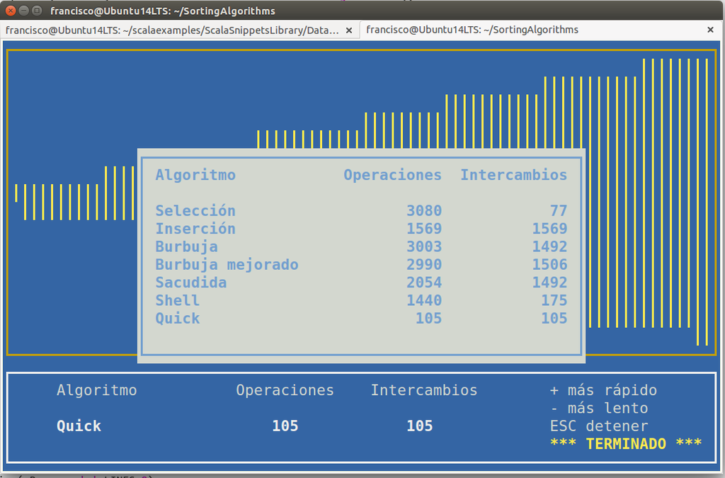

The application running in a console window in Windows

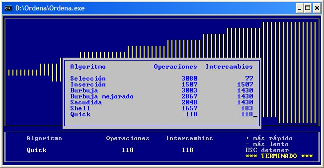

The application running in a console window in OS X

[figure not shown]